# TRABAJO FINAL INTEGRADOR

Modelado de tópicos - LDA

Fauquié - Peiretti - Tapia Serrano

2025-03-12

**Consigna** ¿Cuáles son los tópicos principales en el corpus? ¿Pueden evidenciar diferencias en cada uno de los medios? Explicar qué método se utilizó para responder la pregunta, cuáles son los supuestos del mismo. Generar las visualizaciones más adecuadas para responder a las preguntas.

#### Carga de librerías y de base

```r
library(tidyverse)
library(tidytext)
library(topicmodels)
library(reshape2)
library(ggplot2)
library(ggwordcloud)

bd_clean<-read.csv("../bases/corpus_clean.csv")
```

A continuación sacamos la frecuencia por palabra para LDA por documento

```r
palabras_lda <- bd_clean %>%
  unnest_tokens(output = word, input = texto_limpio) %>%
  group_by(id,word) %>%
  summarise(n=n()) %>%
  ungroup()
```

Calculamos la matriz documento termino

```r
disc_dtm <-palabras_lda %>%
  cast_dtm(id, word, n)
```

Calculamos varios modelos solicitando variaciones en la cantidad de tópicos generados: 7k, 10k, 12k, 15k, 17k. Dado que correr estos modelos lleva tiempo, tras generarlos una primera vez los hemos guardado como objetos de R (y los hemos comprimido). Esto nos permite cargarlos nuevamente para realizar nuestras próximas pruebas sin tener que repetir un proceso tan costoso.

```r
lda_7 <- LDA(disc_dtm, k=7, control = list(seed = 1234)) # Corre en 10 minutos
saveRDS(lda_7, "../bases/modelos-lda/modelo_lda7.rds", compress = "xz")

lda_10 <- LDA(disc_dtm, k=10, control = list(seed = 1234)) # Corre en 15 minutos aprox
saveRDS(lda_10, "../bases/modelos-lda/modelo_lda10.rds", compress = "xz")

lda_12 <- LDA(disc_dtm, k=12, control = list(seed = 1234))
saveRDS(lda_12, "../bases/modelos-lda/modelo_lda12.rds", compress = "xz")

lda_15 <- LDA(disc_dtm, k=15, control = list(seed = 1234))
saveRDS(lda_12, "../bases/modelos-lda/modelo_lda15.rds", compress = "xz")

lda_17 <- LDA(disc_dtm, k=17, control = list(seed = 1234)) # Corre en 1/2 hr aprox
saveRDS(lda_17, "../bases/modelos-lda/modelo_lda17.rds", compress = "xz")
```

Para continuar con el ejercicio, cargamos los modelos ya calculados. Posteriormente, calculamos la matriz beta: problabilidad de cada palbra de pertenecer a un determinado tópico.

```r
lda7 <- readRDS("../bases/modelos-lda/modelo_lda7.rds")
lda10 <- readRDS("../bases/modelos-lda/modelo_lda10.rds")
lda12<- readRDS("../bases/modelos-lda/modelo_lda12.rds")
lda15<- readRDS("../bases/modelos-lda/modelo_lda15.rds")
lda17 <- readRDS("../bases/modelos-lda/modelo_lda17.rds")

ap_topics7 <- tidy(lda7, matrix = "beta") %>%
  mutate(beta = round(100*beta,6))

ap_topics10 <- tidy(lda10, matrix = "beta") %>%
  mutate(beta = round(100*beta,6))

ap_topics12 <- tidy(lda12, matrix = "beta") %>%
  mutate(beta = round(100*beta,6))

ap_topics15 <- tidy(lda15, matrix = "beta") %>%
  mutate(beta = round(100*beta,6))

ap_topics17 <- tidy(lda17, matrix = "beta") %>%
  mutate(beta = round(100*beta,6))
```

Generamos pequeñas tablas para explorar las 10 palabras más importantes de cada tópico, para cada uno de los modelos. El objetivo es identificar las palabras más representativas de cada tópico para poder nombrarlo y diferenciarlo del resto.

```r
ap_top_terms7 <- ap_topics7 %>%
  group_by(topic) %>%
  slice_max(beta, n = 10) %>%
  ungroup() %>%
  arrange(topic, -beta)

ap_top_terms10 <- ap_topics10 %>%
  group_by(topic) %>%
  slice_max(beta, n = 10) %>%
  ungroup() %>%
  arrange(topic, -beta)

ap_top_terms12 <- ap_topics12 %>%
  group_by(topic) %>%
  slice_max(beta, n = 10) %>%
  ungroup() %>%
  arrange(topic, -beta)

ap_top_terms15 <- ap_topics15 %>%
  group_by(topic) %>%
  slice_max(beta, n = 10) %>%
  ungroup() %>%
  arrange(topic, -beta)

ap_top_terms17 <- ap_topics17 %>%
  group_by(topic) %>%
  slice_max(beta, n = 10) %>%
  ungroup() %>%
  arrange(topic, -beta)
```

#### Graficamos

**Modelo k7**

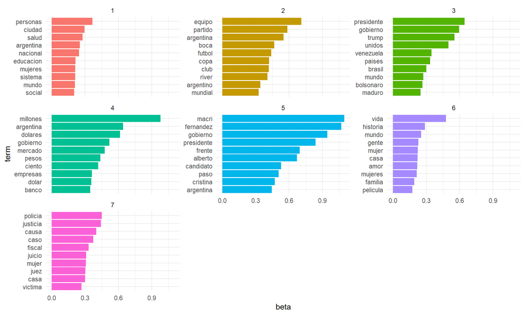

```r
ap_top_terms7 %>%
  mutate(term = reorder_within(term, beta, topic)) %>%
  ggplot(aes(beta, term, fill = factor(topic))) +
  geom_col(show.legend = FALSE) +
  facet_wrap(~ topic, scales='free_y') +
  scale_y_reordered() +
  theme(
    axis.text.x = element_text(size=6)
  )+
  theme_minimal()
```

```r
 ggsave("../visualizaciones/LDA/ap_top_terms7.png", width = 10, height = 6, dpi = 300)
```

**Modelo k10**

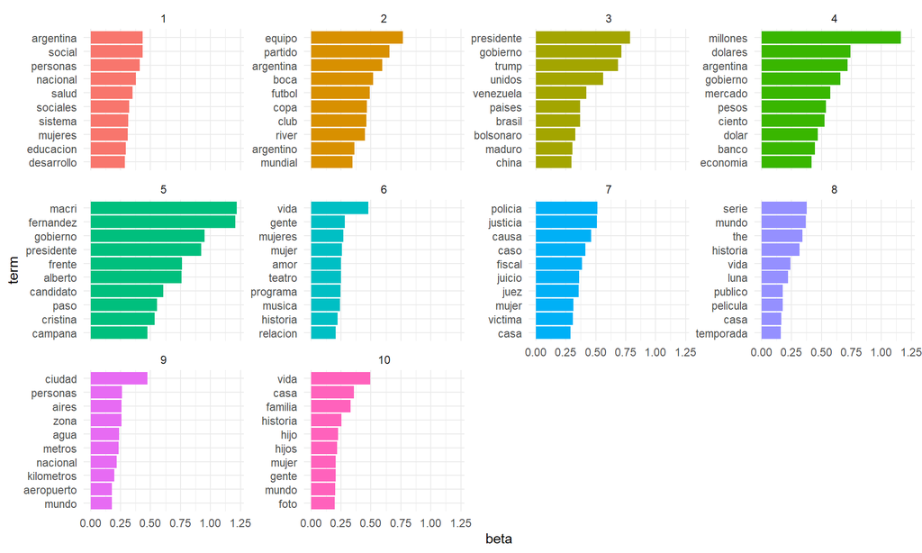

```r
ap_top_terms10 %>%
  mutate(term = reorder_within(term, beta, topic)) %>%
  ggplot(aes(beta, term, fill = factor(topic))) +
  geom_col(show.legend = FALSE) +
  facet_wrap(~ topic, scales='free_y') +
  scale_y_reordered() +
  theme(
    axis.text.x = element_text(size=6)
  )+
  theme_minimal()
```

```r
 ggsave("../visualizaciones/LDA/ap_top_terms10.png", width = 10, height = 6, dpi = 300)
```

**Modelo k12**

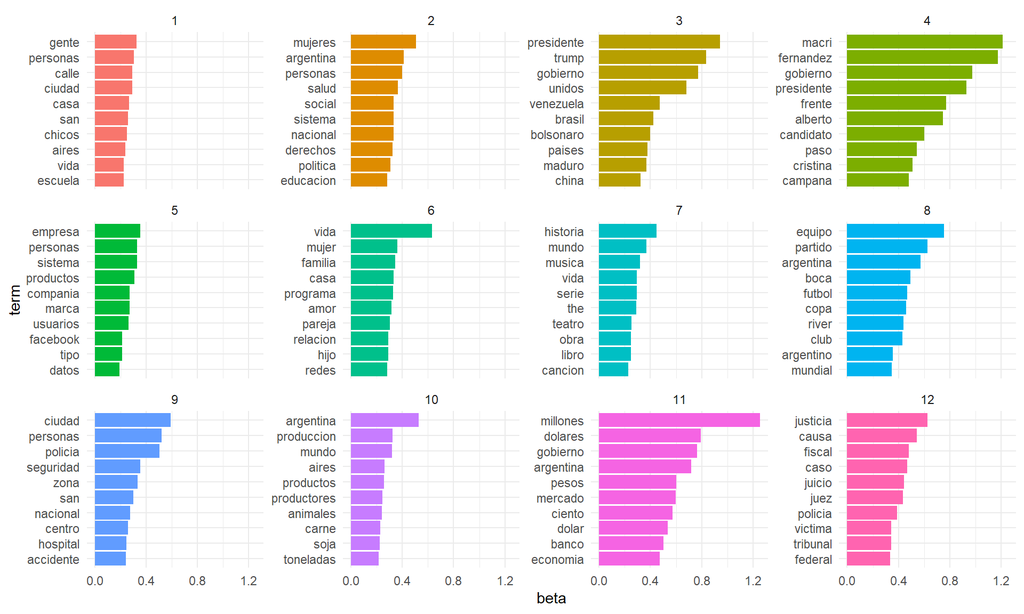

```r
ap_top_terms12 %>%
  mutate(term = reorder_within(term, beta, topic)) %>%
  ggplot(aes(beta, term, fill = factor(topic))) +
  geom_col(show.legend = FALSE) +
  facet_wrap(~ topic, scales='free_y') +
  scale_y_reordered() +
  theme(
    axis.text.x = element_text(size=6)
  )+
  theme_minimal()
```

```r
 ggsave("../visualizaciones/LDA/ap_top_terms12.png", width = 10, height = 6, dpi = 300)
```

**Modelo k15**

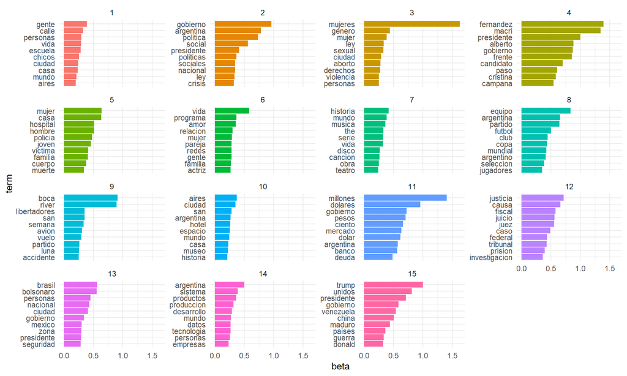

```r
ap_top_terms15 %>%
  mutate(term = reorder_within(term, beta, topic)) %>%
  ggplot(aes(beta, term, fill = factor(topic))) +
  geom_col(show.legend = FALSE) +
  facet_wrap(~ topic, scales='free_y') +
  scale_y_reordered() +
  theme(
    axis.text.x = element_text(size=6)
  )+
  theme_minimal()
```

```r
 ggsave("../visualizaciones/LDA/ap_top_terms15.png", width = 10, height = 6, dpi = 300)
```

**Modelo k17**

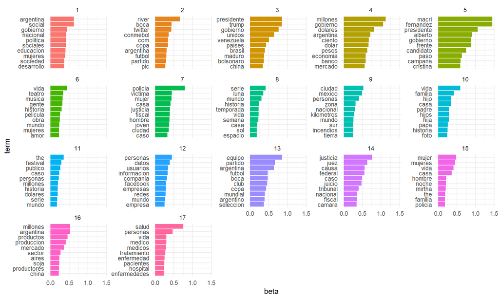

```r
ap_top_terms17 %>%
  mutate(term = reorder_within(term, beta, topic)) %>%
  ggplot(aes(beta, term, fill = factor(topic))) +
  geom_col(show.legend = FALSE) +
  facet_wrap(~ topic, scales='free_y') +
  scale_y_reordered() +
  theme(
    axis.text.x = element_text(size=6)
  )+
  theme_minimal()
```

```r
 ggsave("../visualizaciones/LDA/ap_top_terms17.png", width = 10, height = 6, dpi = 300)
```

Decidimos continuar trabajando con el modelo k12. A partir del mismo, probamos otro tipo de visualizaciones y exploraciones.

#### Nubes de palabras

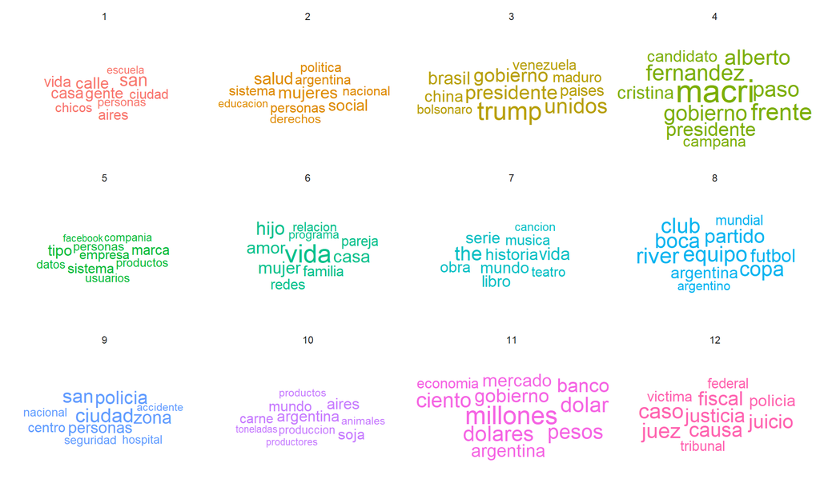

```r
ggplot(ap_top_terms12, aes(label = term, size = beta, color = factor(topic))) +
  geom_text_wordcloud(area_corr = TRUE,  # Mejora la distribución evitando superposición
                      rm_outside = TRUE) +  # Elimina palabras que quedan fuera del área
  facet_wrap(~ topic, scales = "free") +  # Ajusta escalas para cada faceta
  scale_size_area(max_size = 20) +  # Aumenta el tamaño de palabras más importantes
   theme_minimal()
```

```r
 ggsave("../visualizaciones/LDA/nube_palabras2.png", width = 10, height = 6, dpi = 300)
```

#### Nombrando tópicos

A partir de la exploración de las visualizaciones anteriores nos aventuramos a nombras nuestros tópicos.

```r
topic_labels <- c(
  "1" = "Costumbres e interés gral.",
  "2" = "Derechos, educacion y salud",
  "3" = "Política Internacional",
  "4" = "Elecciones nacionales",
  "5"= "Tecnologia y redes soc.",
  "6"= "Chimento y Farándula",
  "7"= "Arte y espectaculos",
  "8"= "Fútbol y deportes",
  "9"= "Siniestros viales",
  "10"= "Agricultura y ganadería",
  "11"= "Economía",
  "12"= "Inseguridad y judiciales"
  )
```

#### Composiciones de tópicos por documento

Realizamos algunas pruebas a través de los valores gamma.

```r
# Calculamos la proporción que representa cada tópico (como tópico principal imputado a una nota) en el total del corpus.
topicos_relevantes <- doc_2_topics %>%
  group_by(topic) %>%
  summarise(mean_gamma = mean(gamma*100)) %>%  # Promedio de gamma por tópico
  arrange(desc(mean_gamma))  # Ordenar de mayor a menor
```

Graficamos la distribución de tópicos para toda la base.

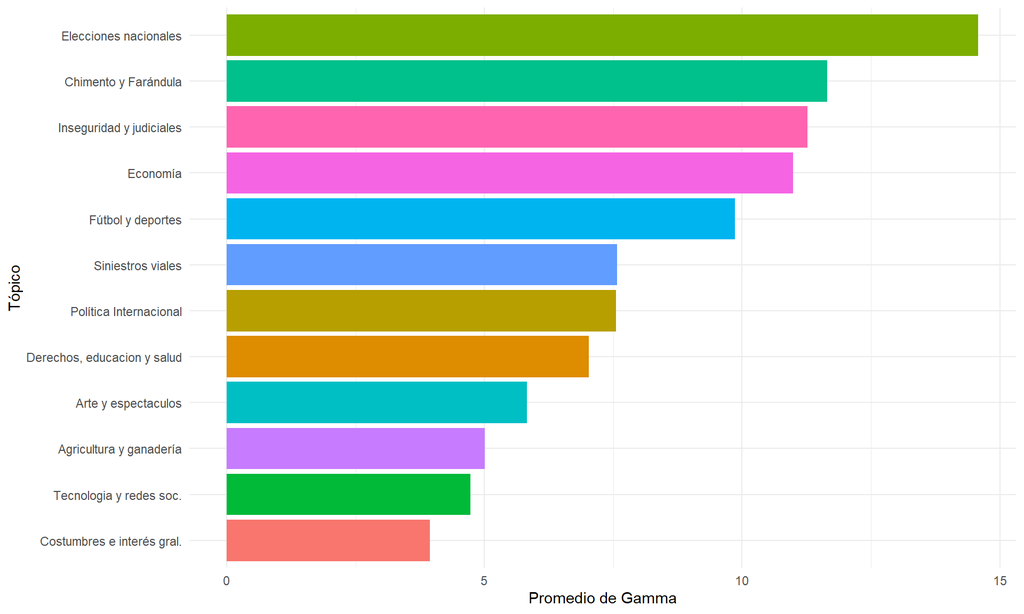

```r
ggplot(topicos_relevantes, aes(x = mean_gamma, y = reorder(factor(topic), mean_gamma), fill = factor(topic))) +
  geom_col(show.legend = FALSE) +
  scale_y_discrete(labels = topic_labels) +  # Etiquetas correctas
  labs(       x = "Promedio de Gamma",
       y = "Tópico") +
  theme_minimal()
```

```r
 ggsave("../visualizaciones/LDA/topicos_relevantes.png", width = 10, height = 6, dpi = 300)
```

Ahora nos proponemos calcular la representación de cada tópico, para cada medio.

```r
b_medios<-bd_clean %>%
  select(id,medio)

gamma_medios <- doc_2_topics %>%
  left_join(b_medios, by = "id") %>%
  group_by(medio, topic) %>%
  summarise(mean = mean(gamma)*100)
# Top2 topicos principales por medio
top_topics_xmedio <- gamma_medios %>%
  group_by(medio) %>%
  slice_max(order_by = mean, n = 2) %>%
  ungroup()
```

Y, por qué no, graficarlo

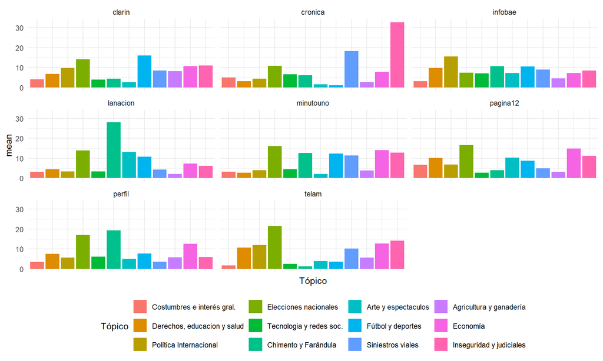

```r
gamma_medios%>%
   ggplot() +
   geom_col(aes(x=as.factor(topic), y=mean, fill=as.factor(topic))) +
    facet_wrap(~ medio)+
  scale_fill_discrete(labels = topic_labels) +
    theme_minimal()+
  labs(
    x = "Tópico",
    y = "mean",
    fill = "Tópico"
  ) +
    theme(
    axis.text.x = element_blank(),
    axis.ticks.x = element_blank(),
    legend.position = "bottom" )
```

```r
 ggsave("../visualizaciones/LDA/topicos_por_medio.png", width = 10, height = 6, dpi = 300)
```

Ahora hacemos lo mismo, pero quedándonos solamente con los dos tópicos más relevantes para una visualización menos cargada.

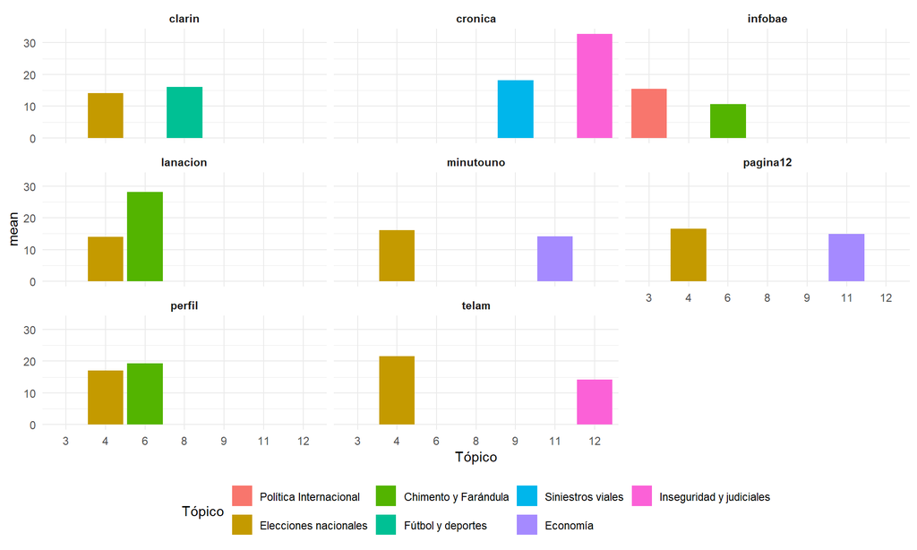

```r
top_topics_xmedio %>%
  ggplot(aes(x = as.factor(topic), y = mean, fill = as.factor(topic))) +  # Convertir topic en factor para colores
  geom_col() +  # Gráfico de barras
  facet_wrap(~ medio) +  # Facetas por medio
  theme_minimal() +  # Estilo limpio
  labs(    x = "Tópico",
    y = "mean",
    fill = "Tópico"
  ) + scale_fill_discrete(labels = topic_labels) +
  theme(
    axis.text.x = element_text(hjust = 0.5),
    strip.text = element_text(face = "bold"),  # Destacar los títulos de las facetas
    legend.position = "bottom"  # Ubicar la leyenda abajo
  )
```

```r
ggsave("../visualizaciones/LDA/ppales_top_x_medio.png", width = 10, height = 6, dpi = 300)
```

#### Creamos base para el ejercicio 3

```r
base_ej3<- doc_2_topics %>%
  group_by(id) %>%       # Agrupar por documento
  slice_max(order_by = gamma, n = 1) %>%  # Seleccionar la fila con el gamma más alto
  ungroup()

# write.csv(base_ej3, "base_ejercicio3.csv")
```